# Data Analysis for stress & coping on Academic performance

Wesal megahed

1-1-2025

# Introduction

The primary objective of this project is to explore how **demographic factors** (such as age, gender, family structure, etc.), **Stress** and **coping mechanisms**, and their combined impact influence **Academic performance**. The aim is to understand how these factors might contribute to or hinder a student’s ability to succeed academically.

By gathering data on these elements, the study will uncover patterns that can offer insights to answer the following Questions:

- **Family Background**: How does family structure (e.g., single-parent families, dual-parent families) influence stress and academic performance?
- **Educational Level**: Does a student’s level of education (high school, undergraduate, etc.) impact their stress levels and coping strategies?
- **Access to Resources**: How do factors like digital access contribute to a student’s success?
- **Stress Levels**: What types of stress do students experience, and how do they perceive their stress level in relation to their studies?
- **Coping Strategies**: What coping mechanisms are most commonly employed by students, and how do these mechanisms influence their academic outcomes?
- **Interaction of Factors**: How do demographic factors (e.g., family background, age) interact with stress levels and coping strategies to influence academic performance?
- **Academic Success or Failure**: How do these combined factors contribute to a student’s ability to succeed academically, and what patterns can be identified?

# Data Analysis

Below, we will present a summary of the data and apply statistical analysis techniques such as confidence intervals, hypothesis testing, regression analysis to interpret the data.

```r
options(warn=-1)

library(readxl)
library(ggplot2)    # For visualizations
library(dplyr)      # For data manipulation
library(psych)      # For descriptive statistics
library(janitor)    # clean names
library(knitr)      # tables

# Load the dataset(this is example for group 8)
data <- read_excel("8 Demographics, stress & coping and Academic performance.xlsx")

# Clean the dataset
data <- data %>% clean_names()
names(data)[names(data) == "academic_performance_questions"] <- "GPA"
names(data)[names(data) == "on_a_scale_from_1_lowest_to_10_highest_how_would_you_rate_your_general_stress_level_over_the_past_month"] <- "Stress_levels"
names(data)[names(data) == "lifestyle_factors_urban_vs_rural_living"] <- "lifestyle"
names(data)[names(data) == "impact_of_stress_on_grades" ] <- "stress_impact"
colnames(data)
```

```
##  [1] "id"                       "start_time"
##  [3] "completion_time"          "email"
##  [5] "name"                     "gender"
##  [7] "age"                      "parents_education_level"
##  [9] "parents_education_level1" "family_structure"
## [11] "lifestyle"                "digital_access"
## [13] "Stress_levels"            "stress_sources"
## [15] "coping_strategies"        "frequency_of_coping"
## [17] "effectiveness_of_coping"  "GPA"
## [19] "time_spent_studying"      "stress_impact"
```

```r
#------------------------ Statistical Summaries -------------------#

## Central tendency measures
summary(data)
```

```
##        id          start_time
##  Min.   : 1.00   Min.   :2024-11-09 14:47:04.00
##  1st Qu.:13.75   1st Qu.:2024-11-10 14:09:30.00
##  Median :26.50   Median :2024-11-11 13:20:27.00
##  Mean   :26.50   Mean   :2024-11-11 05:07:29.98
##  3rd Qu.:39.25   3rd Qu.:2024-11-11 15:20:45.00
##  Max.   :52.00   Max.   :2024-11-12 08:57:18.00
##  completion_time                     email             name
##  Min.   :2024-11-09 14:54:08.00   Length:52          Mode:logical
##  1st Qu.:2024-11-10 14:12:17.25   Class :character   NA's:52
##  Median :2024-11-11 13:22:21.00   Mode  :character
##  Mean   :2024-11-11 05:11:51.69
##  3rd Qu.:2024-11-11 15:34:19.00
##  Max.   :2024-11-12 09:01:46.00
##     gender               age        parents_education_level
##  Length:52          Min.   :11.00   Length:52
##  Class :character   1st Qu.:18.00   Class :character
##  Mode  :character   Median :19.00   Mode  :character
##                     Mean   :22.67
##                     3rd Qu.:21.25
##                     Max.   :66.00
##  parents_education_level1 family_structure    lifestyle
##  Length:52                Length:52          Length:52
##  Class :character         Class :character   Class :character
##  Mode  :character         Mode  :character   Mode  :character
##
##
##
##  digital_access     Stress_levels     stress_sources     coping_strategies
##  Length:52          Min.   :  2.000   Length:52          Length:52
##  Class :character   1st Qu.:  6.000   Class :character   Class :character
##  Mode  :character   Median :  8.000   Mode  :character   Mode  :character
##                     Mean   :  9.135
##                     3rd Qu.:  9.250
##                     Max.   :100.000
##  frequency_of_coping effectiveness_of_coping      GPA
##  Min.   :   0.00     Length:52               Min.   :  0.00
##  1st Qu.:   3.00     Class :character        1st Qu.:  5.00
##  Median :   7.00     Mode  :character        Median :  7.00
##  Mean   :  52.47                             Mean   : 18.81
##  3rd Qu.:  10.00                             3rd Qu.: 10.00
##  Max.   :2009.00                             Max.   :115.00
##  time_spent_studying stress_impact
##  Min.   :   0.00     Length:52
##  1st Qu.:   5.00     Class :character
##  Median :   7.00     Mode  :character
##  Mean   :  59.88
##  3rd Qu.:  21.75
##  Max.   :2007.00
```

```r
# Perform statistical summaries
summary_table <- data %>%
  summarise(
    `Total Records` = n(),
    `Age (Mean)` = mean(age),
    `Age (Median)` = median(age),
    `Coping Frequency (Mean)` = mean(frequency_of_coping),
    `Coping Frequency (Median)` = median(frequency_of_coping),
    `Time Studying (Mean)` = mean(time_spent_studying),
    `Time Studying (Median)` = median(time_spent_studying),
    `Academic Performance (Mean)` = mean(GPA),
    `Academic Performance (Median)` = median(GPA)
  )

# Convert to a professional table format
kable(summary_table, caption = "Statistical Summary of the Dataset", digits = 2)
```

Statistical Summary of the Dataset

| Total Records | Age (Mean) | Age (Median) | Coping Frequency (Mean) | Coping Frequency (Median) | Time Studying (Mean) | Time Studying (Median) | Academic Performance (Mean) | Academic Performance (Median) |
| --- | --- | --- | --- | --- | --- | --- | --- | --- |
| 52 | 22.67 | 19 | 52.47 | 7 | 59.88 | 7 | 18.81 | 7 |

```r
# Variability measures
variability_age <- data %>%
  summarise(
    `Total Records` = n(),
    `Mean Age` = mean(age),
    `Variance Age` = var(age),
    `Standard Deviation Age` = sd(age),
    `Min Age` = min(age),
    `Max Age` = max(age),
    `Range Age` = diff(range(age)),
    `Q1 Age` = quantile(age, 0.25),
    `Median Age` = median(age),
    `Q3 Age` = quantile(age, 0.75),
    `IQR Age` = IQR(age))
kable(variability_age,caption = "Variability Measures of the Dataset",digits = 2)
```

Variability Measures of the Dataset

| Total Records | Mean Age | Variance Age | Standard Deviation Age | Min Age | Max Age | Range Age | Q1 Age | Median Age | Q3 Age | IQR Age |
| --- | --- | --- | --- | --- | --- | --- | --- | --- | --- | --- |
| 52 | 22.67 | 113.32 | 10.65 | 11 | 66 | 55 | 18 | 19 | 21.25 | 3.25 |

```r
variability_gpa <- data %>%
  summarise(
`Mean GPA` = mean(GPA),
`Variance GPA` = var(GPA),
`Standard Deviation GPA` = sd(GPA),
`Min GPA` = min(GPA),
`Max GPA` = max(GPA),
`Range GPA` = diff(range(GPA)),
`Q1 GPA` = quantile(GPA, 0.25),
`Median GPA` = median(GPA),
`Q3 GPA` = quantile(GPA, 0.75),
`IQR GPA` = IQR(GPA))
kable(variability_gpa,caption = "Variability Measures of the Dataset",digits = 2)
```

Variability Measures of the Dataset

| Mean GPA | Variance GPA | Standard Deviation GPA | Min GPA | Max GPA | Range GPA | Q1 GPA | Median GPA | Q3 GPA | IQR GPA |
| --- | --- | --- | --- | --- | --- | --- | --- | --- | --- |
| 18.81 | 989.57 | 31.46 | 0 | 115 | 115 | 5 | 7 | 10 | 5 |

```r
variability_Time_studying <- data %>%
  summarise(
    `Mean Time Spent Studying` = mean(time_spent_studying),
`Variance Time Spent Studying` = var(time_spent_studying),
`Standard Deviation Time Spent Studying` = sd(time_spent_studying),
`Min Time Spent Studying` = min(time_spent_studying),
`Max Time Spent Studying` = max(time_spent_studying),
`Range Time Spent Studying` = diff(range(time_spent_studying)),
`Q1 Time Spent Studying` = quantile(time_spent_studying, 0.25),
`Median Time Spent Studying` = median(time_spent_studying),
`Q3 Time Spent Studying` = quantile(time_spent_studying, 0.75),
`IQR Time Spent Studying` = IQR(time_spent_studying))
kable(variability_Time_studying,caption = "Variability Measures of the Dataset",digits = 2)
```

Variability Measures of the Dataset

| Mean Time Spent Studying | Variance Time Spent Studying | Standard Deviation Time Spent Studying | Min Time Spent Studying | Max Time Spent Studying | Range Time Spent Studying | Q1 Time Spent Studying | Median Time Spent Studying | Q3 Time Spent Studying | IQR Time Spent Studying |
| --- | --- | --- | --- | --- | --- | --- | --- | --- | --- |
| 59.88 | 77886.81 | 279.08 | 0 | 2007 | 2007 | 5 | 7 | 21.75 | 16.75 |

```r
variability_Coping_hour <- data %>%
  summarise(
`Mean Frequency of Coping` = mean(frequency_of_coping),
`Variance Frequency of Coping` = var(frequency_of_coping),
`Standard Deviation Frequency of Coping` = sd(frequency_of_coping),
`Min Frequency of Coping` = min(frequency_of_coping),
`Max Frequency of Coping` = max(frequency_of_coping),
`Range Frequency of Coping` = diff(range(frequency_of_coping)),
`Q1 Frequency of Coping` = quantile(frequency_of_coping, 0.25),
`Median Frequency of Coping` = median(frequency_of_coping),
`Q3 Frequency of Coping` = quantile(frequency_of_coping, 0.75),
`IQR Frequency of Coping` = IQR(frequency_of_coping))
kable(variability_Coping_hour,caption = "Variability Measures of the Dataset",digits = 2)
```

Variability Measures of the Dataset

| Mean Frequency of Coping | Variance Frequency of Coping | Standard Deviation Frequency of Coping | Min Frequency of Coping | Max Frequency of Coping | Range Frequency of Coping | Q1 Frequency of Coping | Median Frequency of Coping | Q3 Frequency of Coping | IQR Frequency of Coping |
| --- | --- | --- | --- | --- | --- | --- | --- | --- | --- |
| 52.47 | 77223.1 | 277.89 | 0 | 2009 | 2009 | 3 | 7 | 10 | 7 |

```r
table(data$gender)
```

```
##
## Female   Male
##     17     35
```

```r
table(data$parents_education_level)
```

```
##
##         No formal education              Primary school
##                           1                           4
##            Secondary school University degree or higher
##                           5                          42
```

```r
table(data$gender)# ------------------- Data Visualization -------------- #
```

```
##
## Female   Male
##     17     35
```

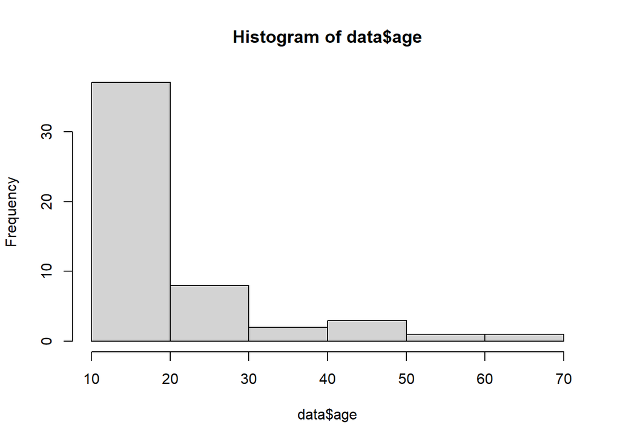

```r
# 1. Histogram for Age
hist(data$age)
```

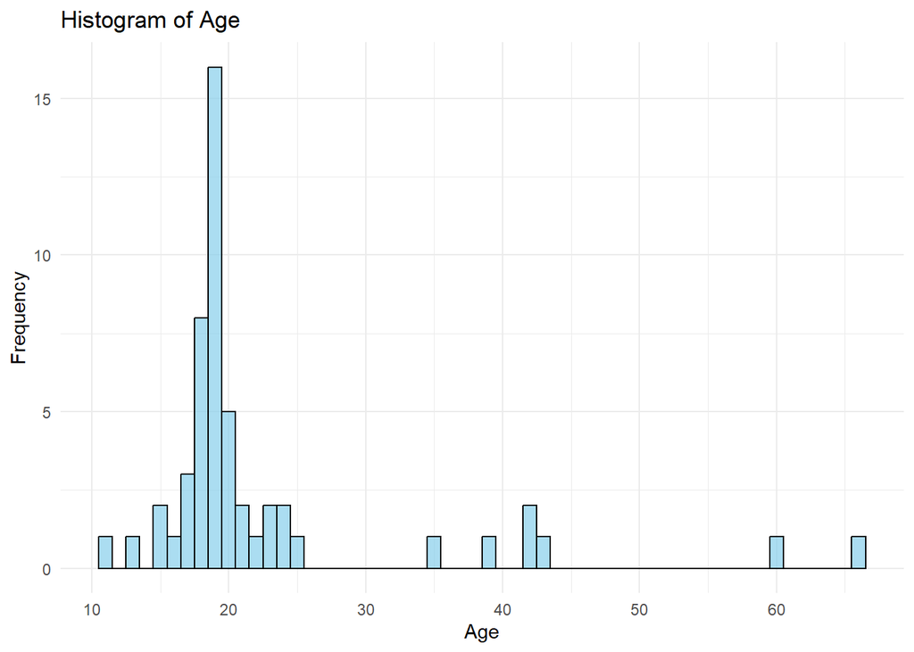

```r
ggplot(data, aes(x = age)) +
  geom_histogram(binwidth = 1, fill = "skyblue", color = "black", alpha = 0.7) +
  labs(title = "Histogram of Age", x = "Age", y = "Frequency") +
  theme_minimal()
```

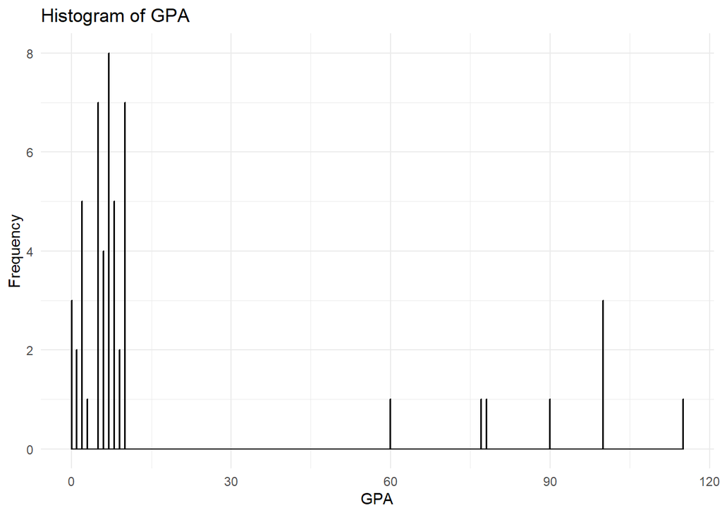

```r
# 2. Histogram for GPA
ggplot(data, aes(x = GPA)) +
  geom_histogram(binwidth = 0.1, fill = "orange", color = "black", alpha = 0.7) +
  labs(title = "Histogram of GPA", x = "GPA", y = "Frequency") +
  theme_minimal()
```

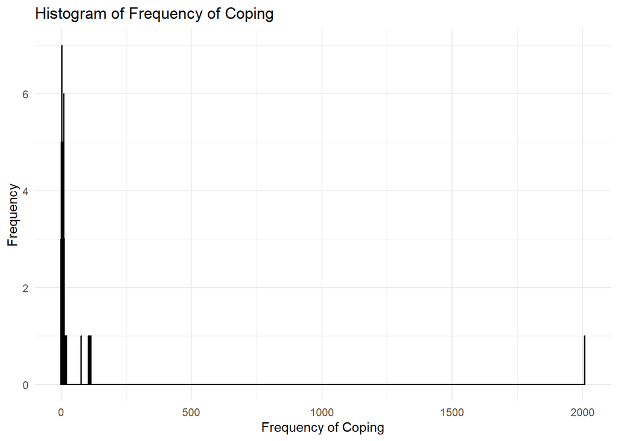

```r
# 3. Histogram for Time Spent Studying
ggplot(data, aes(x = frequency_of_coping)) +
  geom_histogram(binwidth = 1, fill = "green", color = "black", alpha = 0.7) +
  labs(title = "Histogram of Frequency of Coping", x = "Frequency of Coping", y = "Frequency") +
  theme_minimal()
```

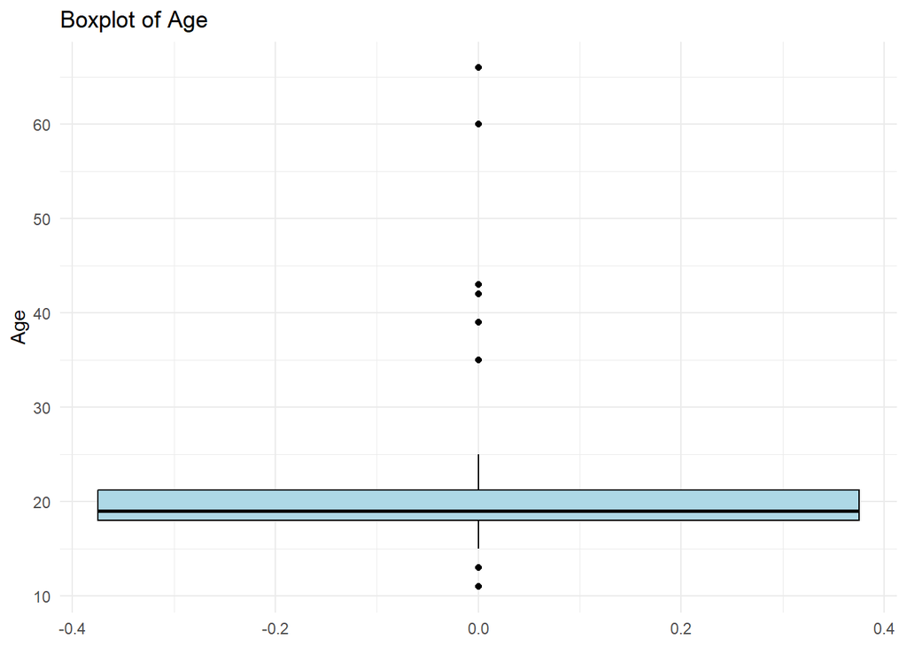

```r
# 3. Boxplot for Age
ggplot(data, aes(y = age)) +
  geom_boxplot(fill = "lightblue", color = "black") +
  labs(title = "Boxplot of Age", y = "Age") +
  theme_minimal()
```

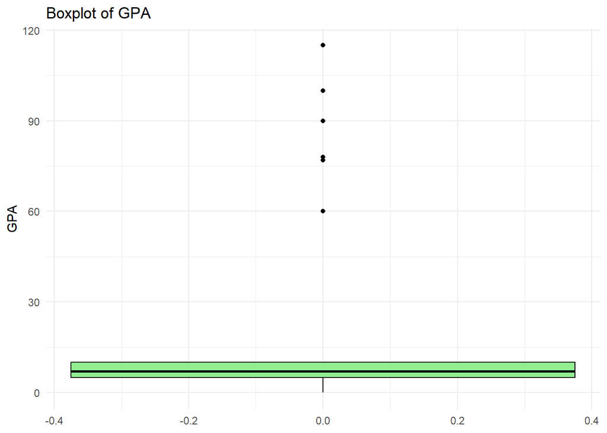

```r
# 4. Boxplot for GPA
ggplot(data, aes(y = GPA)) +
  geom_boxplot(fill = "lightgreen", color = "black") +
  labs(title = "Boxplot of GPA", y = "GPA") +
  theme_minimal()
```

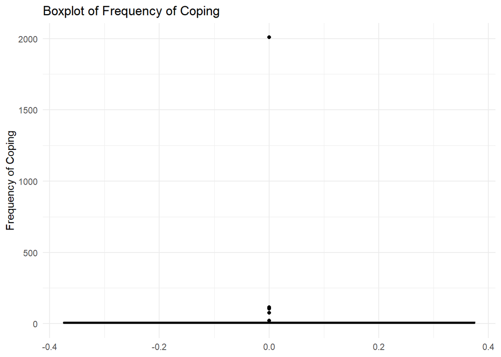

```r
# 5. Boxplot for Frequency of Coping
ggplot(data, aes(y = frequency_of_coping)) +
  geom_boxplot(fill = "lightcoral", color = "black") +
  labs(title = "Boxplot of Frequency of Coping", y = "Frequency of Coping") +
  theme_minimal()
```

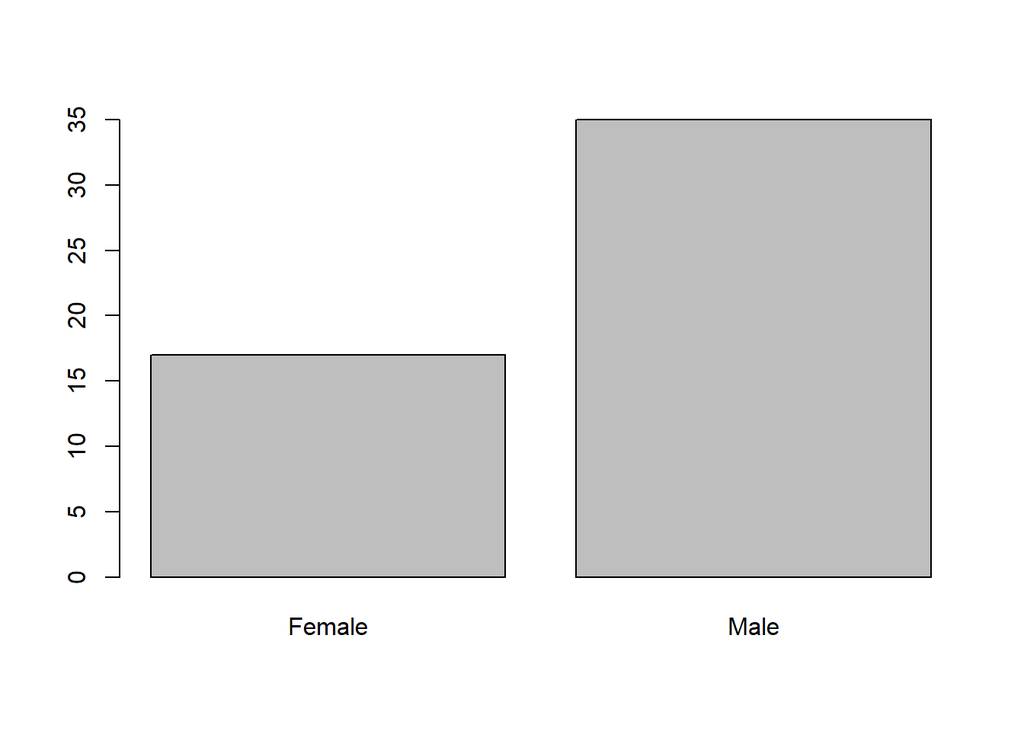

```r
# 7. Bar Plot for Gender
barplot(table(data$gender))
```

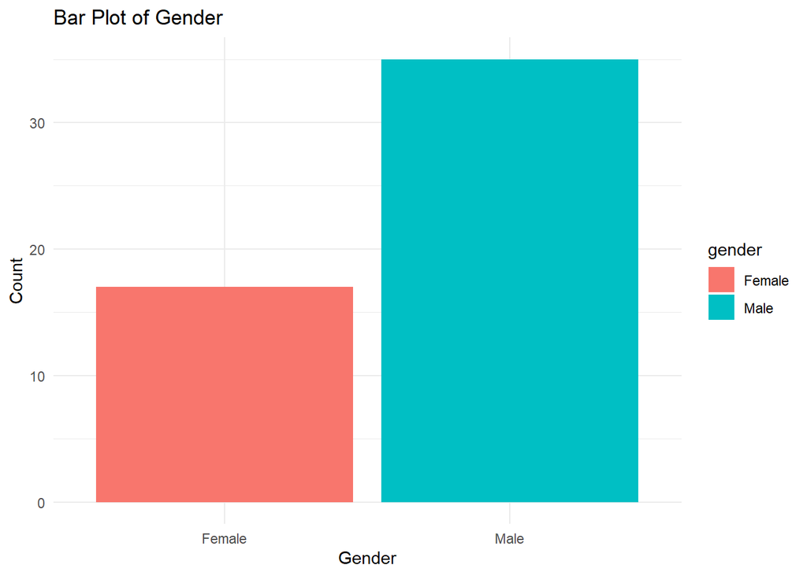

```r
ggplot(data, aes(x = gender, fill = gender)) +
  geom_bar() +
  labs(title = "Bar Plot of Gender", x = "Gender", y = "Count") +
  theme_minimal()
```

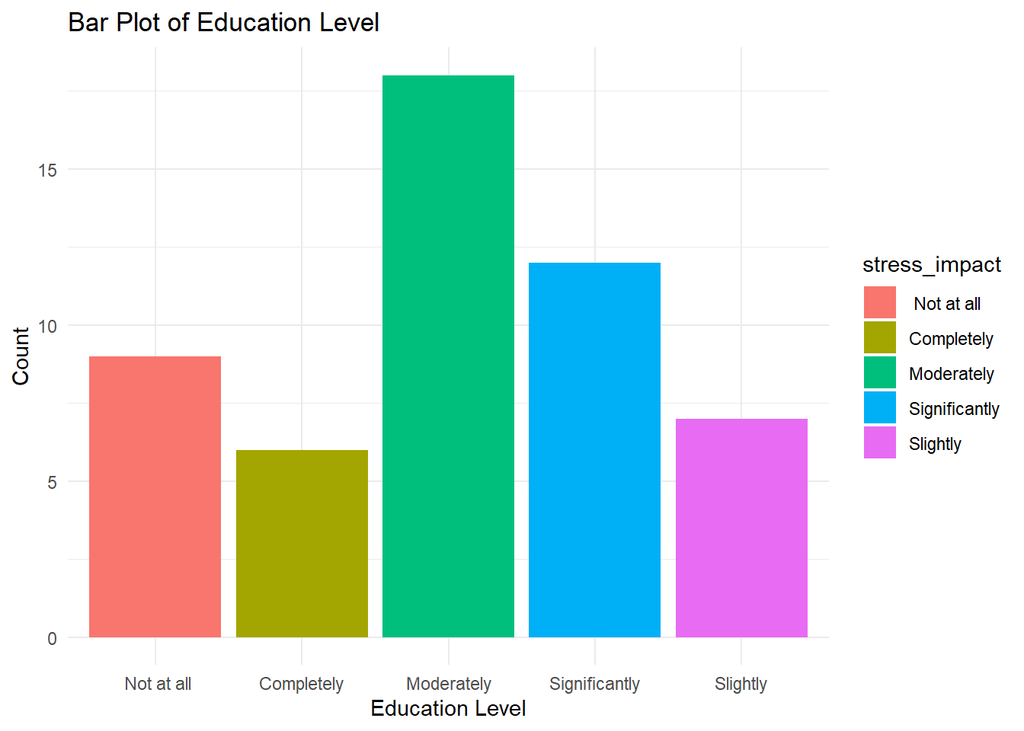

```r
# 8. Bar Plot for impact of stress on grades
ggplot(data, aes(x = stress_impact, fill = stress_impact)) +
  geom_bar() +
  labs(title = "Bar Plot of Education Level", x = "Education Level", y = "Count") +
  theme_minimal()
```

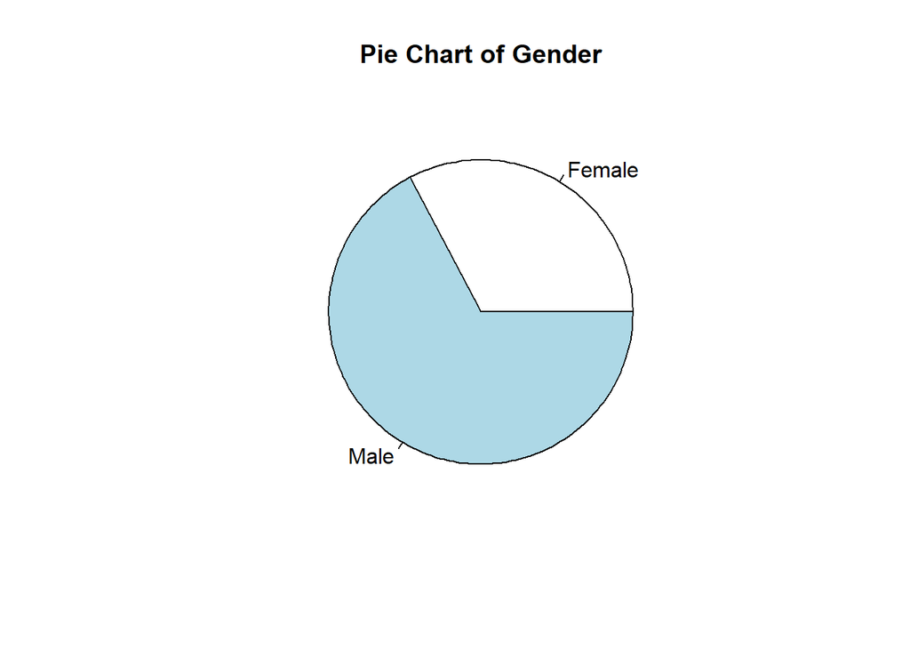

```r
pie(table(data$gender), main = "Pie Chart of Gender")
```

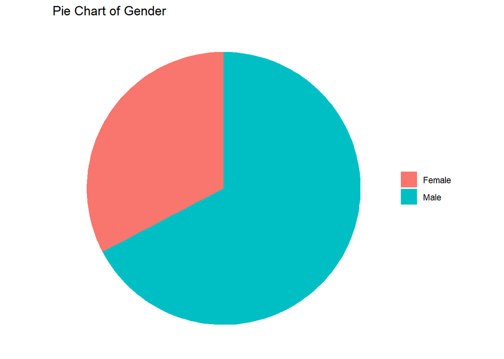

```r
ggplot(data, aes(x = "", fill = gender)) +
  geom_bar(stat = "count", width = 1) +
  coord_polar(theta = "y") +
  labs(title = "Pie Chart of Gender") +
  theme_void() +
  theme(legend.title = element_blank())
```

```r
#----------------------- Detect and replace outliers ---------------------#
# Define a function to detect and replace outliers

replace_outliers_with_median <- function(column) {
  Q1 <- quantile(column, 0.25, na.rm = TRUE)
  Q3 <- quantile(column, 0.75, na.rm = TRUE)
  IQR <- Q3 - Q1
  lower_bound <- Q1 - 1.5 * IQR
  upper_bound <- Q3 + 1.5 * IQR
  column <- ifelse(column < lower_bound | column > upper_bound,
                   median(column, na.rm = TRUE),
                   column)
  return(column)}

# Apply the function to numeric columns in your dataset using mutate function
data_cleaned <- data %>%
  mutate(across(where(is.numeric), replace_outliers_with_median))
```

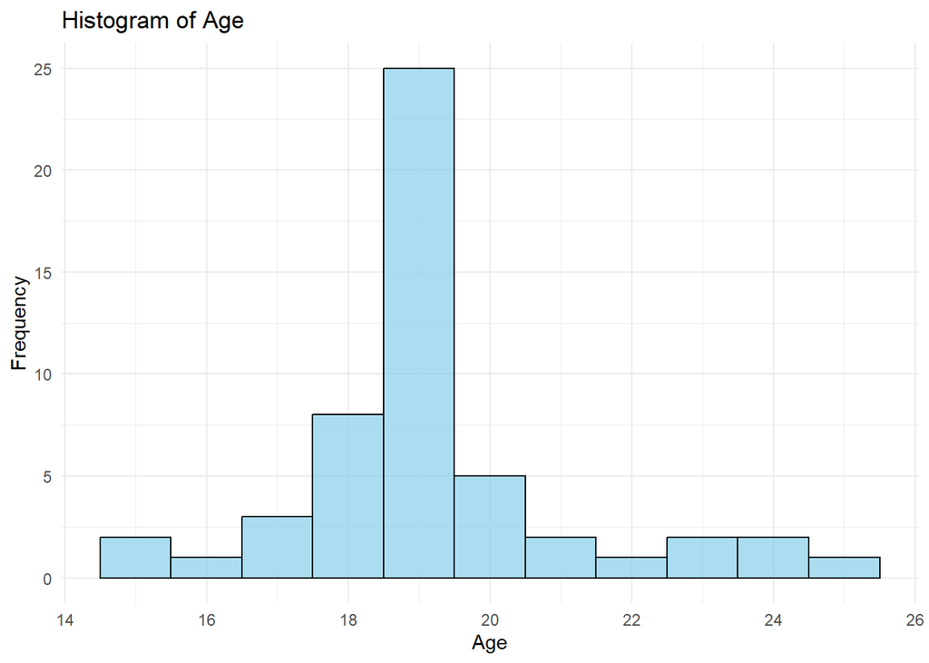

```r
# 2. Histogram for Age
ggplot(data_cleaned, aes(x = age)) +
  geom_histogram(binwidth = 1, fill = "skyblue", color = "black", alpha = 0.7) +
  labs(title = "Histogram of Age", x = "Age", y = "Frequency") +
  theme_minimal()
```

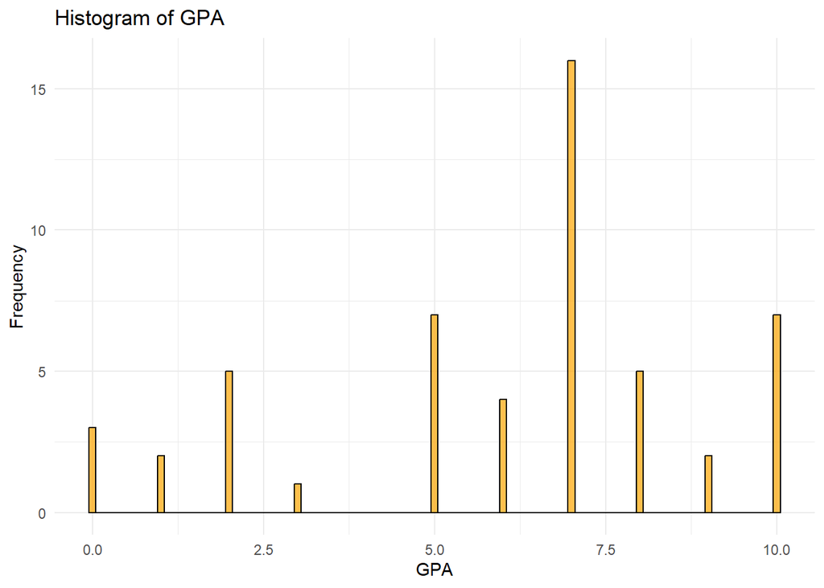

```r
# 2. Histogram for GPA
ggplot(data_cleaned, aes(x = GPA)) +
  geom_histogram(binwidth = 0.1, fill = "orange", color = "black", alpha = 0.7) +
  labs(title = "Histogram of GPA", x = "GPA", y = "Frequency") +
  theme_minimal()
```

```r
#####
# Proportions (%) of each category: Example for gender
(table(data$gender)/length(data$gender))*100
```

```
##
##   Female     Male
## 32.69231 67.30769
```

```r
# Or use probability table
prop.table(table(data$gender)) * 100
```

```
##
##   Female     Male
## 32.69231 67.30769
```

```r
# to round up to one decimal
round(prop.table(table(data$gender)) * 100, 1)
```

```
##
## Female   Male
##   32.7   67.3
```

```r
# Create a contingency table (Count)
table(data_cleaned$gender, data_cleaned$digital_access)
```

```
##
##          Excellent access Good access Limited access Moderate access
##   Female                3           8              2               4
##   Male                 14          14              1               6
```

```r
table(data_cleaned$family_structure, data_cleaned$Stress_levels)
```

```
##
##                              2 3 4 5 6 7 8 9 10
##    Extended family household 2 0 1 0 2 2 6 3  3
##    Single-parent household   1 0 0 0 0 1 2 1  1
##   I Live alone               0 0 0 0 0 0 0 0  1
##   Separated parents          0 0 0 1 0 0 0 0  0
##   Two-parent household       0 1 1 2 5 4 5 0  7
```

```r
table(data_cleaned$parents_education_level,data_cleaned$parents_education_level1)
```

```
##
##                               No formal education Primary school
##   No formal education                           1              0
##   Primary school                                0              1
##   Secondary school                              1              0
##   University degree or higher                   0              2
##
##                               Secondary school University degree or higher
##   No formal education                        0                           0
##   Primary school                             2                           1
##   Secondary school                           2                           2
##   University degree or higher                2                          38
```

```r
#possible comment (Most parents with a University Degree or Higher tend to have partners or family members with similar education levels )

# Create a contingency table (proportion)
round(prop.table(table(data_cleaned$gender, data_cleaned$digital_access)) * 100, 1)
```

```
##
##          Excellent access Good access Limited access Moderate access
##   Female              5.8        15.4            3.8             7.7
##   Male               26.9        26.9            1.9            11.5
```

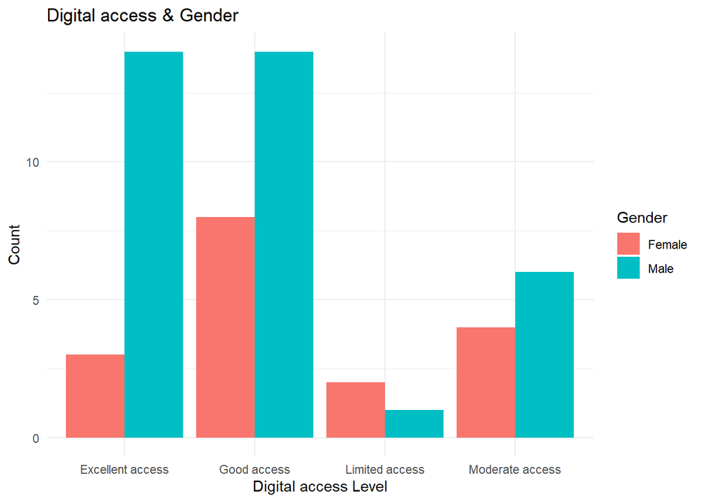

```r
# Plot clustered bar chart for two qualitative variables
ggplot(data_cleaned, aes(x = digital_access, fill = gender)) +
  geom_bar(position = "dodge") +
  labs(title = "Digital access & Gender",
       x = "Digital access Level",
       y = "Count",
       fill = "Gender") +
  theme_minimal()
```

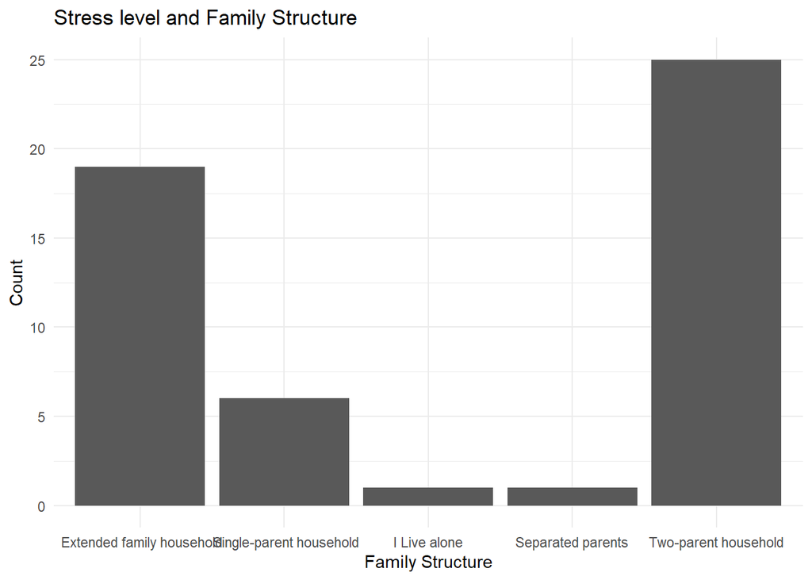

```r
ggplot(data_cleaned, aes(x = family_structure, fill = Stress_levels)) +
  geom_bar(position = "dodge") +
  labs(title = "Stress level and Family Structure",
       x = "Family Structure",
       y = "Count",
       fill = "stress Level") +
  theme(axis.text.x = element_text(angle = 45, hjust = 1)) +
  theme_minimal()
```

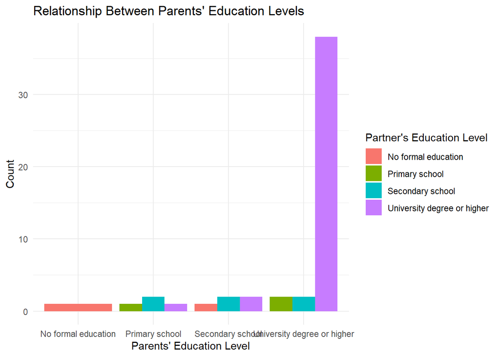

```r
# Graph for parents_education_level & parents_education_level1
ggplot(data_cleaned, aes(x = parents_education_level, fill = parents_education_level1)) +
  geom_bar(position = "dodge") +
  labs(title = "Relationship Between Parents' Education Levels",
       x = "Parents' Education Level",
       y = "Count",
       fill = "Partner's Education Level") +
  theme(axis.text.x = element_text(angle = 45, hjust = 1)) +
  theme_minimal()
```

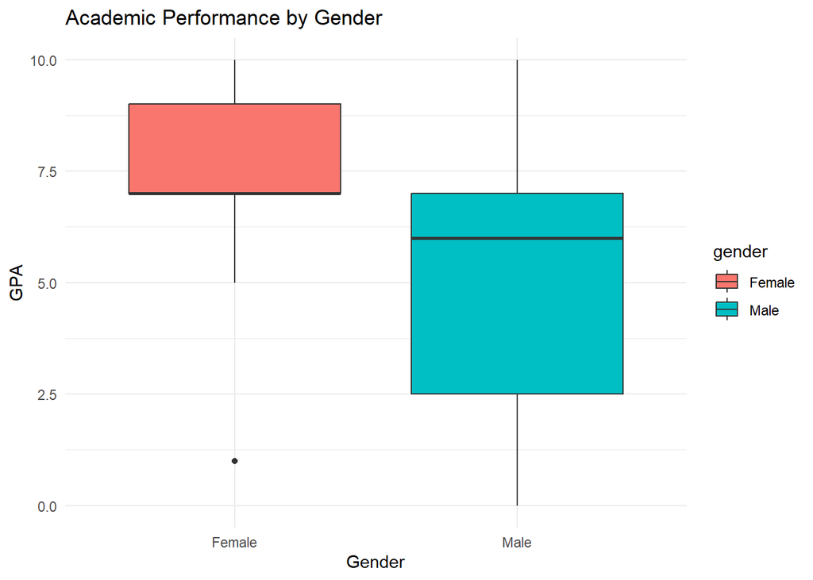

```r
#--------------------------------------
#Plot box plot for  qualitative and Quantitative variables
ggplot(data_cleaned, aes(x = gender, y = GPA, fill = gender)) +
  geom_boxplot() +
  labs(title = "Academic Performance by Gender",
       x = "Gender",
       y = "GPA") +
  theme_minimal()
```

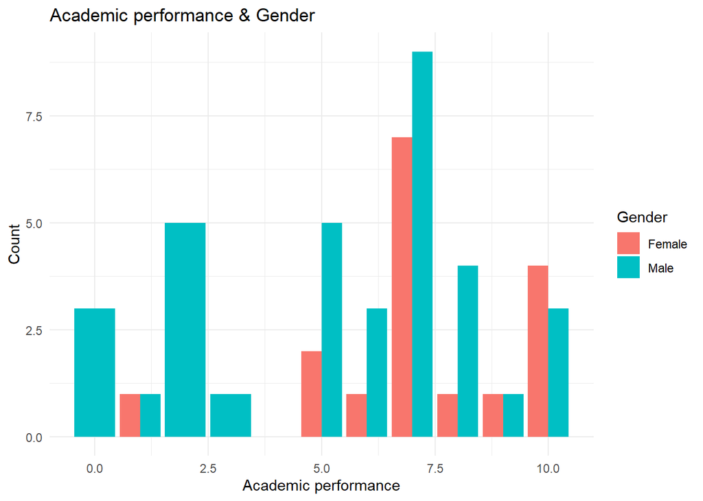

```r
ggplot(data_cleaned, aes(x = GPA, fill = gender)) +
  geom_bar(position = "dodge") +
  labs(title = "Academic performance & Gender",
       x = "Academic performance",
       y = "Count",
       fill = "Gender") +
  theme_minimal()
```

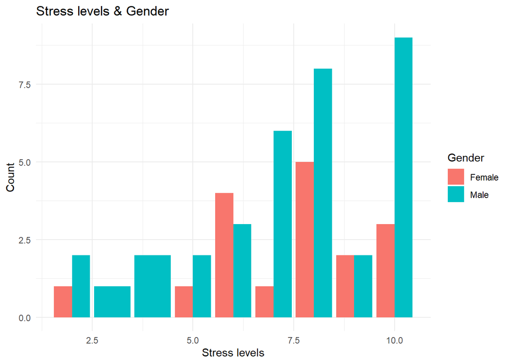

```r
ggplot(data_cleaned, aes(x = Stress_levels, fill = gender)) +
  geom_bar(position = "dodge") +
  labs(title = "Stress levels & Gender",
       x = "Stress levels",
       y = "Count",
       fill = "Gender") +
  theme_minimal()
```

```r
#----------------------for overlapped variables (more than one answer per response)
#stress_sources
table(data_cleaned$stress_sources)
```

```
##
##                                                                        Academic workload;
##                                                                                        17
##                  Academic workload;Family issues;Financial problems;Social relationships;
##                                                                                         1
##                                                     Academic workload;Financial problems;
##                                                                                         1
##                                                        Academic workload;Health concerns;
##                                                                                         1
##                                                   Academic workload;Social relationships;
##                                                                                         1
##                                                                                    Exams;
##                                                                                         1
##                                                                            Family issues;
##                                                                                         7
##                                                         Family issues; Academic workload;
##                                                                                         2
##                                                          Family issues;Responsibilities ;
##                                                                                         1
##                                                                       Financial problems;
##                                                                                         4
##                                                    Financial problems; Academic workload;
##                                                                                         1
##                                      Financial problems; Academic workload;Family issues;
##                                                                                         1
##                 Financial problems;Family issues; Academic workload;Social relationships;
##                                                                                         1
##                                                                          Health concerns;
##                                                                                         2
##                Health concerns;Financial problems;Family issues;War effects, Immigration;
##                                                                                         1
## Health concerns;Social relationships;Financial problems;Family issues; Academic workload;
##                                                                                         1
##                                                                                 Nothing ;
##                                                                                         1
##                                                                                    Other;
##                                                                                         1
##                                                                     Social relationships;
##                                                                                         2
##                                                  Social relationships; Academic workload;
##                                                                                         1
##                                                       Social relationships;Family issues;
##                                                                                         1
##                                                  Social relationships;Financial problems;
##                                                                                         1
##                                                                             The Gaza war;
##                                                                                         1
##                                                                                      War;
##                                                                                         1
```

```r
# Step 1: Clean and process the data
Stress_Source <- unlist(strsplit(data_cleaned$stress_sources, "[;\n]")) # Split by semicolon and newline
Stress_Source <- trimws(Stress_Source)               # Remove whitespace
Stress_Source <- Stress_Source[Stress_Source != ""]       # Remove empty strings

# Step 2: Create a frequency table
frequency_Stress_Source <- table(Stress_Source)
frequency_Stress_Source
```

```
## Stress_Source
##        Academic workload                    Exams            Family issues
##                       28                        1                       16
##       Financial problems          Health concerns                  Nothing
##                       12                        5                        1
##                    Other         Responsibilities     Social relationships
##                        1                        1                        9
##             The Gaza war                      War War effects, Immigration
##                        1                        1                        1
```

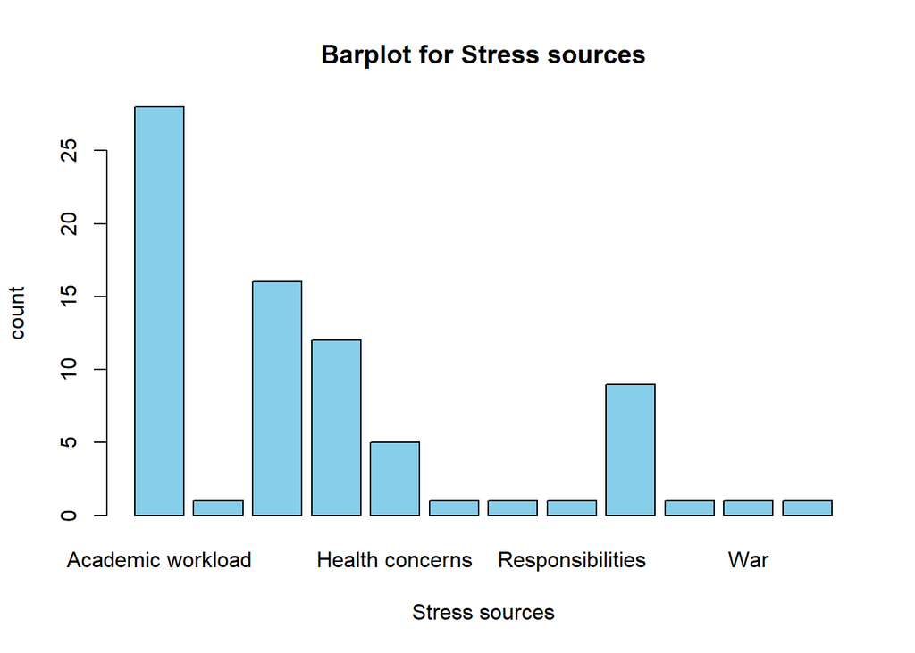

```r
barplot(frequency_Stress_Source, main = "Barplot for Stress sources", xlab = "Stress sources", ylab = "count", col = "skyblue")
```

```r
### Coping Strategies
# Step 1: Clean and process the data
coping_strategies <- unlist(strsplit(data_cleaned$coping_strategies, "[;\n]")) # Split by semicolon and newline
coping_strategies <- trimws(coping_strategies)               # Remove whitespace
coping_strategies <- coping_strategies[coping_strategies != ""]       # Remove empty strings

# Step 2: Create a frequency table
frequency_coping_strategies <- table(coping_strategies)
frequency_coping_strategies
```

```
## coping_strategies
##                     Exercise                    Going out
##                           16                            1
##       Meditation/mindfulness      Professional counseling
##                           12                            7
## Self professional counseling    Talking to friends/family
##                            1                           30
##   Time management techniques                      Walking
##                           12                            1
```

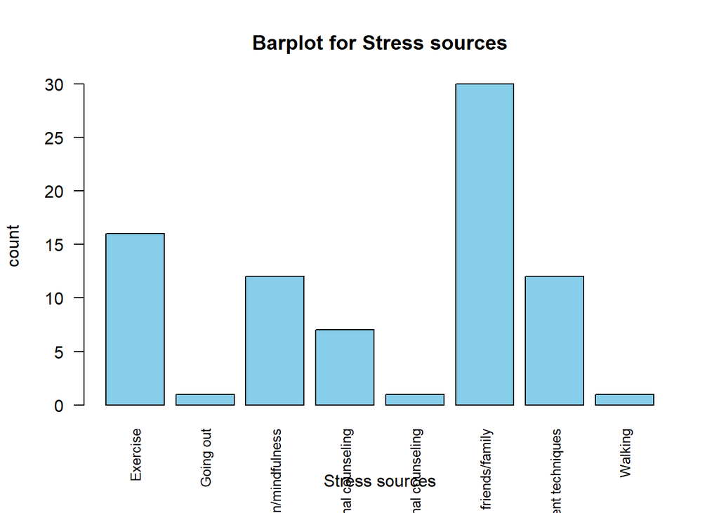

```r
barplot(frequency_coping_strategies, main = "Barplot for Stress sources", xlab = "Stress sources", ylab = "count", col = "skyblue",las = 2, cex.names = 0.8)
```

# Confidence Interval (CI)

A confidence interval is used to estimate a range of values that is likely to contain the population parameter. For example, if we want to estimate the mean GPA of all students based on a sample,we would calculate the confidence interval for **the Sample mean GPA**.

```r
# Point Estimate for the population mean (GPA for All student in college)
Estimated_population_mean = mean(data_cleaned$GPA)
Estimated_population_mean
```

```
## [1] 6.038462
```

```r
# 1- 95% Confidence Interval for GPA
confidence_level <- 0.95
z_value <- qnorm(1 - (1 - confidence_level) / 2)  # z=1.96 for 95% CI
z_value
```

```
## [1] 1.959964
```

```r
# Calculate margin of error
n = length(data_cleaned$GPA)
margin_of_error <- z_value * (sd(data_cleaned$GPA) / sqrt(n))

# Calculate confidence interval
CI_lower <- Estimated_population_mean - margin_of_error
CI_upper <- Estimated_population_mean + margin_of_error
CI = c(CI_lower, CI_upper)
CI
```

```
## [1] 5.258548 6.818375
```

- This means we are 95% confident that the true population mean GPA lies between **5.259 and 6.818**.
- The margin of error is 0.780 (rounded), indicating **the estimate’s precision**. As smaller margin of error suggests more precision in the estimate of the population mean of GPA.

# Hypothesis Testing

We’ll conduct hypothesis tests to validate or reject assumptions about the data.

- Test Conducted: One-sample z-test on the GPA variable to determine if the true mean of GPA is significantly different from 2. # Case (1)- Two Sided
- Null Hypothesis (H₀): The true mean GPA is equal to 2.
- Alternative Hypothesis (H₁): The true mean GPA is not equal to 2.

```r
#install.packages("BSDA")
library("BSDA")
z.test(data_cleaned$GPA,
       mu = 2, sigma.x =sd(data_cleaned$GPA),
       conf.level = 0.95, alternative = "two.sided")
```

```
##
##  One-sample z-Test
##
## data:  data_cleaned$GPA
## z = 10.149, p-value < 2.2e-16
## alternative hypothesis: true mean is not equal to 2
## 95 percent confidence interval:
##  5.258548 6.818375
## sample estimates:
## mean of x
##  6.038462
```

- Reject H₀ and accept alternative hypothesis: true mean is not equal to 2
- Coinfidence Interval: [ 5.258548 - 6.818375 ]

```r
# Case (2)- one Side (Right tail)
z.test(data_cleaned$GPA,
       mu = 2, sigma.x =sd(data_cleaned$GPA),
       conf.level = 0.95, alternative = "greater")
```

```
##
##  One-sample z-Test
##
## data:  data_cleaned$GPA
## z = 10.149, p-value < 2.2e-16
## alternative hypothesis: true mean is greater than 2
## 95 percent confidence interval:
##  5.383938       NA
## sample estimates:
## mean of x
##  6.038462
```

- Reject H₀ and accept alternative hypothesis: true mean greater than 2
- Coinfidence Interval: [ 5.383938 - infinity ]

```r
# Case (3)- one Side (left tail)
z.test(data_cleaned$GPA,
       mu = 2, sigma.x =sd(data_cleaned$GPA),
       conf.level = 0.95, alternative = "greater")
```

```
##
##  One-sample z-Test
##
## data:  data_cleaned$GPA
## z = 10.149, p-value < 2.2e-16
## alternative hypothesis: true mean is greater than 2
## 95 percent confidence interval:
##  5.383938       NA
## sample estimates:
## mean of x
##  6.038462
```

- Reject H₀ and accept alternative hypothesis: true mean greater than 2
- Coinfidence Interval: [ 5.383938 - infinity ]

# A common test to begin with is the t-test, depending on the nature of the data.

```r
# One-sample t-test to test if the mean GPA is significantly different from 6.0
t_test_result <- t.test(data_cleaned$GPA, mu = 6.0)
t_test_result
```

```
##
##  One Sample t-test
##
## data:  data_cleaned$GPA
## t = 0.096656, df = 51, p-value = 0.9234
## alternative hypothesis: true mean is not equal to 6
## 95 percent confidence interval:
##  5.239599 6.837324
## sample estimates:
## mean of x
##  6.038462
```

- The p-value of 0.9234 is much greater than the typical significance level of 0.05. Therefore, we fail to reject the null hypothesis.
- This means there is no significant evidence to suggest that the true mean of GPA is different from 6.

```r
# One-sample t-test for testing if the mean GPA is greater than 6
t_test_result <- t.test(data_cleaned$GPA, mu = 6, alternative = "greater")
t_test_result
```

```
##
##  One Sample t-test
##
## data:  data_cleaned$GPA
## t = 0.096656, df = 51, p-value = 0.4617
## alternative hypothesis: true mean is greater than 6
## 95 percent confidence interval:
##  5.371829      Inf
## sample estimates:
## mean of x
##  6.038462
```

- Since the p-value (0.4617) is much higher than the significance level (0.05), we fail to reject the null hypothesis.
- This means there isn’t sufficient evidence to claim that the mean GPA is greater than 6.

# Regression Analysis

we can explore relationships between variables, such as how stress levels and coping strategies affect academic performance (GPA).

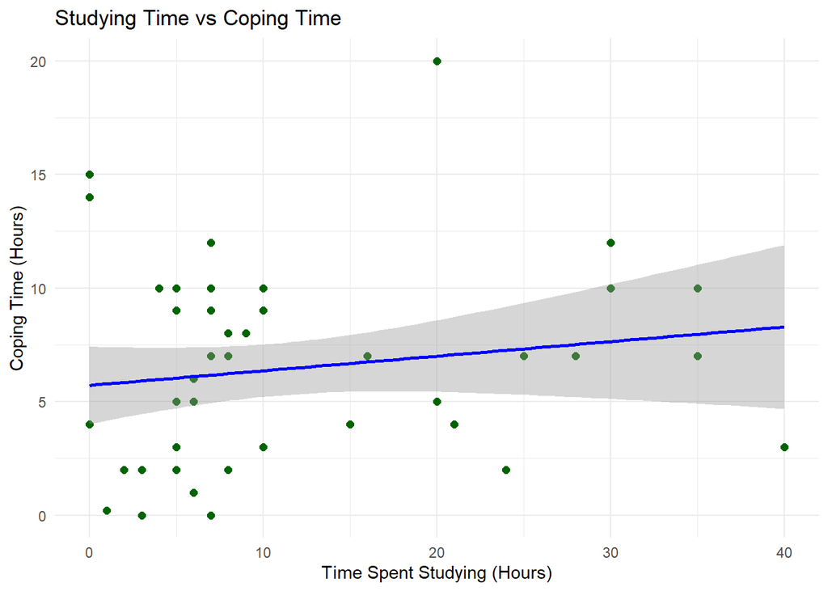

```r
ggplot(data_cleaned, aes(x = time_spent_studying, y = frequency_of_coping)) +
  geom_point(color = "darkgreen", size = 2) +
  geom_smooth(method = "lm", col = "blue", se = TRUE) +  # Add confidence interval with se = TRUE
  labs(title = "Studying Time vs Coping Time",
       x = "Time Spent Studying (Hours)",
       y = "Coping Time (Hours)") +
  theme_minimal()
```

```r
# Split the dataset by family structure and perform linear regression
#to Apply regression for each group
family_groups <- split(data_cleaned, data_cleaned$family_structure)
regressions <- lapply(family_groups, function(df) {lm(GPA ~ Stress_levels, data = df)})
lapply(regressions, summary)     # Display summary for each group
```

```
## $` Extended family household`
##
## Call:
## lm(formula = GPA ~ Stress_levels, data = df)
##
## Residuals:
##     Min      1Q  Median      3Q     Max
## -5.2548 -1.1512  0.3468  1.3468  4.5460
##
## Coefficients:
##               Estimate Std. Error t value Pr(>|t|)
## (Intercept)     7.2467     2.2289   3.251   0.0047 **
## Stress_levels  -0.1992     0.2902  -0.686   0.5017
## ---
## Signif. codes:  0 '***' 0.001 '**' 0.01 '*' 0.05 '.' 0.1 ' ' 1
##
## Residual standard error: 2.961 on 17 degrees of freedom
## Multiple R-squared:  0.02697,    Adjusted R-squared:  -0.03027
## F-statistic: 0.4712 on 1 and 17 DF,  p-value: 0.5017
##
##
## $` Single-parent household`
##
## Call:
## lm(formula = GPA ~ Stress_levels, data = df)
##
## Residuals:
##       1       2       3       4       5       6
##  0.2881 -0.8051  1.9237 -0.8898  2.9237 -3.4407
##
## Coefficients:
##               Estimate Std. Error t value Pr(>|t|)
## (Intercept)     2.1610     3.1338   0.690    0.528
## Stress_levels   0.3644     0.4035   0.903    0.417
##
## Residual standard error: 2.53 on 4 degrees of freedom
## Multiple R-squared:  0.1694, Adjusted R-squared:  -0.03825
## F-statistic: 0.8158 on 1 and 4 DF,  p-value: 0.4175
##
##
```

[output cut: 36 more lines]

```
##
## Residuals:
##     Min      1Q  Median      3Q     Max
## -7.1565 -0.4682  0.7612  1.7612  3.5318
##
## Coefficients:
##               Estimate Std. Error t value Pr(>|t|)
## (Intercept)     4.8624     2.2441   2.167   0.0409 *
## Stress_levels   0.2294     0.2926   0.784   0.4409
## ---
## Signif. codes:  0 '***' 0.001 '**' 0.01 '*' 0.05 '.' 0.1 ' ' 1
##
## Residual standard error: 2.955 on 23 degrees of freedom
## Multiple R-squared:  0.02604,    Adjusted R-squared:  -0.01631
## F-statistic: 0.6149 on 1 and 23 DF,  p-value: 0.4409
```

- There is no strong or significant relationship between stress levels and GPA in the Extended family household.
- Slope: -0.1992 (Negative relationship; as stress levels increase, GPA decreases slightly, but the effect is not significant).

```r
# Perform One-Way ANOVA (Example on parents_education_level)
anova_result <- aov(GPA ~ parents_education_level, data = data_cleaned)
summary_anova <- summary(anova_result)
print(summary_anova)
```

```
##                         Df Sum Sq Mean Sq F value Pr(>F)
## parents_education_level  3   22.0   7.327   0.884  0.456
## Residuals               48  397.9   8.290
```

```r
# P-value interpretation
p_value_anova <- summary_anova[[1]][["Pr(>F)"]][1]
if (p_value_anova < 0.05) {
  cat("There is a significant difference in GPA between education level groups.\n")
} else {
  cat("There is no significant difference in GPA between education level groups.\n")
}
```

```
## There is no significant difference in GPA between education level groups.
```

- The p-value (0.456) is greater than 0.05, which indicates that the differences in GPA between the levels of parents’ education level are not statistically significant at the 5% significance level.
- This means that there is no sufficient evidence to conclude that the GPA differs based on parents’ education level.
- The variation in GPA scores is mostly due to random chance rather than a significant effect of parents’ education level.
- parents_education_level (Between Groups): 22.0 — variability explained by the group differences.

```r
# Perform One-Way ANOVA (on gender)
anova_result <- aov(GPA ~ gender, data = data_cleaned)
summary_anova <- summary(anova_result)
print(summary_anova)
```

```
##             Df Sum Sq Mean Sq F value Pr(>F)
## gender       1   36.2   36.18   4.714 0.0347 *
## Residuals   50  383.7    7.67
## ---
## Signif. codes:  0 '***' 0.001 '**' 0.01 '*' 0.05 '.' 0.1 ' ' 1
```

```r
# P-value interpretation
p_value_anova <- summary_anova[[1]][["Pr(>F)"]][1]
if (p_value_anova < 0.05) {
  cat("There is a significant difference in GPA between education level groups.\n")
} else {
  cat("There is no significant difference in GPA between education level groups.\n")
}
```

```
## There is a significant difference in GPA between education level groups.
```

```r
# Regression analysis:  GPA based on time spent studying
model <- lm(GPA ~ time_spent_studying, data = data_cleaned)
summary(model)
```

```
##
## Call:
## lm(formula = GPA ~ time_spent_studying, data = data_cleaned)
##
## Residuals:
##     Min      1Q  Median      3Q     Max
## -6.0709 -1.0380  0.9628  1.9337  3.9712
##
## Coefficients:
##                     Estimate Std. Error t value Pr(>|t|)
## (Intercept)         6.020345   0.594914  10.120 1.08e-13 ***
## time_spent_studying 0.001685   0.040805   0.041    0.967
## ---
## Signif. codes:  0 '***' 0.001 '**' 0.01 '*' 0.05 '.' 0.1 ' ' 1
##
## Residual standard error: 2.898 on 50 degrees of freedom
## Multiple R-squared:  3.411e-05,  Adjusted R-squared:  -0.01997
## F-statistic: 0.001706 on 1 and 50 DF,  p-value: 0.9672
```

```r
anova_results <- anova(model)
anova_results
```

```
## Analysis of Variance Table
##
## Response: GPA
##                     Df Sum Sq Mean Sq F value Pr(>F)
## time_spent_studying  1   0.01  0.0143  0.0017 0.9672
## Residuals           50 419.91  8.3982
```

- There is no significant relationship between time spent studying and GPA.
- The slope coefficient (0.0017) is not significant (p>0.05), and the R-squared value shows that time spent studying explains an insignificant portion of the GPA variance.
- This suggests that factors other than time spent studying are likely influencing GPA.

```r
regressions <- lapply(family_groups, function(df) {lm(GPA ~ time_spent_studying, data = df)})
lapply(regressions, summary)
```

```
## $` Extended family household`
##
## Call:
## lm(formula = GPA ~ time_spent_studying, data = df)
##
## Residuals:
##    Min     1Q Median     3Q    Max
## -4.768 -1.122  0.534  1.139  3.534
##
## Coefficients:
##                     Estimate Std. Error t value Pr(>|t|)
## (Intercept)          7.52456    0.82436   9.128  5.8e-08 ***
## time_spent_studying -0.15122    0.05239  -2.886   0.0103 *
## ---
## Signif. codes:  0 '***' 0.001 '**' 0.01 '*' 0.05 '.' 0.1 ' ' 1
##
## Residual standard error: 2.459 on 17 degrees of freedom
## Multiple R-squared:  0.3289, Adjusted R-squared:  0.2894
## F-statistic: 8.331 on 1 and 17 DF,  p-value: 0.01025
##
##
## $` Single-parent household`
##
## Call:
## lm(formula = GPA ~ time_spent_studying, data = df)
##
## Residuals:
##       1       2       3       4       5       6
##  0.9078  0.6854  2.4631 -1.6476 -0.5388 -1.8699
##
## Coefficients:
##                     Estimate Std. Error t value Pr(>|t|)
## (Intercept)           2.9806     1.1307   2.636   0.0578 .
## time_spent_studying   0.2223     0.1005   2.213   0.0913 .
## ---
## Signif. codes:  0 '***' 0.001 '**' 0.01 '*' 0.05 '.' 0.1 ' ' 1
##
## Residual standard error: 1.862 on 4 degrees of freedom
## Multiple R-squared:  0.5504, Adjusted R-squared:  0.438
## F-statistic: 4.897 on 1 and 4 DF,  p-value: 0.09133
```

[output cut: 38 more lines]

```
##
## Residuals:
##     Min      1Q  Median      3Q     Max
## -5.4484 -0.8408  0.2288  1.0833  3.9504
##
## Coefficients:
##                     Estimate Std. Error t value Pr(>|t|)
## (Intercept)          5.11920    0.81667   6.268 2.14e-06 ***
## time_spent_studying  0.13292    0.05669   2.345    0.028 *
## ---
## Signif. codes:  0 '***' 0.001 '**' 0.01 '*' 0.05 '.' 0.1 ' ' 1
##
## Residual standard error: 2.69 on 23 degrees of freedom
## Multiple R-squared:  0.1929, Adjusted R-squared:  0.1578
## F-statistic: 5.498 on 1 and 23 DF,  p-value: 0.02804
```

```r
#-----------------------------------------------------------------------------------
# Compare GPA across family structures
family_gpa <- aggregate(GPA ~ family_structure, data = data_cleaned, mean)
family_gpa
```

```
##             family_structure      GPA
## 1  Extended family household 5.789474
## 2    Single-parent household 4.833333
## 3               I Live alone 3.000000
## 4          Separated parents 8.000000
## 5       Two-parent household 6.560000
```

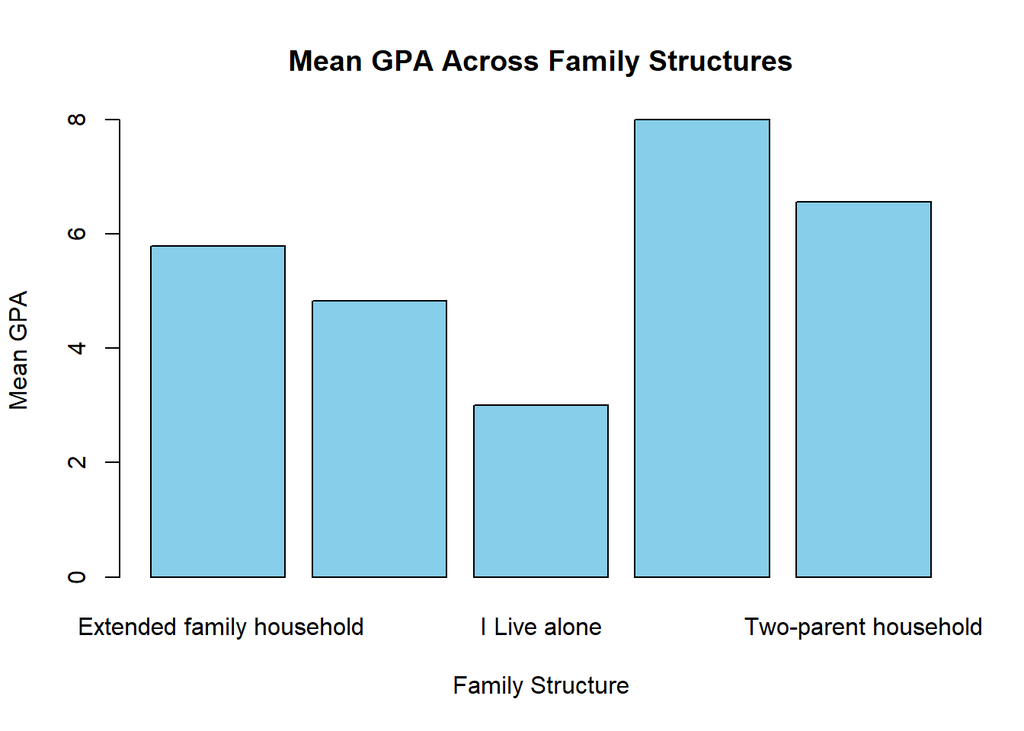

```r
# Create bar plot
barplot(family_gpa$GPA,
        names.arg = family_gpa$family_structure,
        col = "skyblue",
        main = "Mean GPA Across Family Structures",
        ylab = "Mean GPA",
        xlab = "Family Structure")
```

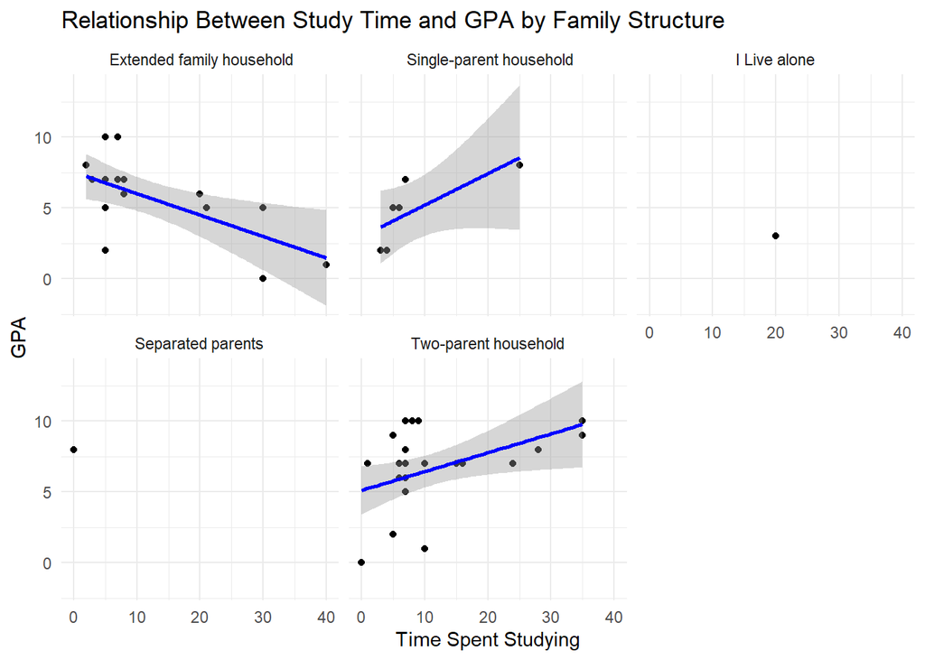

```r
ggplot(data_cleaned, aes(x = time_spent_studying, y = GPA)) +
  geom_point() +
  geom_smooth(method = "lm", col = "blue") +
  facet_wrap(~ family_structure) +
  labs(title = "Relationship Between Study Time and GPA by Family Structure",
       x = "Time Spent Studying",
       y = "GPA") +
  theme_minimal()
```

```r
# Regression model: GPA ~ stress_levels + family_structure + digital_access
model <- lm(GPA ~ Stress_levels + family_structure + digital_access + age, data = data_cleaned)
summary(model)
```

```
##
## Call:
## lm(formula = GPA ~ Stress_levels + family_structure + digital_access +
##     age, data = data_cleaned)
##
## Residuals:
##     Min      1Q  Median      3Q     Max
## -6.1925 -1.1842  0.3935  1.6870  4.9217
##
## Coefficients:
##                                          Estimate Std. Error t value Pr(>|t|)
## (Intercept)                                8.0516     4.6597   1.728   0.0913 .
## Stress_levels                              0.0414     0.1913   0.216   0.8298
## family_structure Single-parent household  -0.8562     1.3906  -0.616   0.5414
## family_structureI Live alone              -2.2595     3.1376  -0.720   0.4754
## family_structureSeparated parents          2.6288     3.1968   0.822   0.4155
## family_structureTwo-parent household       0.7831     0.9074   0.863   0.3930
## digital_accessGood access                  1.3121     0.9787   1.341   0.1872
## digital_accessLimited access               0.9531     1.8676   0.510   0.6125
## digital_accessModerate access              0.1500     1.2439   0.121   0.9046
## age                                       -0.1687     0.2165  -0.779   0.4402
## ---
## Signif. codes:  0 '***' 0.001 '**' 0.01 '*' 0.05 '.' 0.1 ' ' 1
##
## Residual standard error: 2.952 on 42 degrees of freedom
## Multiple R-squared:  0.1286, Adjusted R-squared:  -0.05811
## F-statistic: 0.6888 on 9 and 42 DF,  p-value: 0.7148
```

```r
#Coefficients will show how stress levels and family background influence GPA, accounting for age and digital access.

# Apply linear regression (Stress Levels ~ GPA) for each family group
stress_regressions <- lapply(family_groups, function(df) {lm(GPA ~ Stress_levels, data = df)})
lapply(stress_regressions, summary)      # Display regression summaries for each group
```

```
## $` Extended family household`
##
## Call:
## lm(formula = GPA ~ Stress_levels, data = df)
##
## Residuals:
##     Min      1Q  Median      3Q     Max
## -5.2548 -1.1512  0.3468  1.3468  4.5460
##
## Coefficients:
##               Estimate Std. Error t value Pr(>|t|)
## (Intercept)     7.2467     2.2289   3.251   0.0047 **
## Stress_levels  -0.1992     0.2902  -0.686   0.5017
## ---
## Signif. codes:  0 '***' 0.001 '**' 0.01 '*' 0.05 '.' 0.1 ' ' 1
##
## Residual standard error: 2.961 on 17 degrees of freedom
## Multiple R-squared:  0.02697,    Adjusted R-squared:  -0.03027
## F-statistic: 0.4712 on 1 and 17 DF,  p-value: 0.5017
##
##
## $` Single-parent household`
##
## Call:
## lm(formula = GPA ~ Stress_levels, data = df)
##
## Residuals:
##       1       2       3       4       5       6
##  0.2881 -0.8051  1.9237 -0.8898  2.9237 -3.4407
##
## Coefficients:
##               Estimate Std. Error t value Pr(>|t|)
## (Intercept)     2.1610     3.1338   0.690    0.528
## Stress_levels   0.3644     0.4035   0.903    0.417
##
## Residual standard error: 2.53 on 4 degrees of freedom
## Multiple R-squared:  0.1694, Adjusted R-squared:  -0.03825
## F-statistic: 0.8158 on 1 and 4 DF,  p-value: 0.4175
##
##
```

[output cut: 36 more lines]

```
##
## Residuals:
##     Min      1Q  Median      3Q     Max
## -7.1565 -0.4682  0.7612  1.7612  3.5318
##
## Coefficients:
##               Estimate Std. Error t value Pr(>|t|)
## (Intercept)     4.8624     2.2441   2.167   0.0409 *
## Stress_levels   0.2294     0.2926   0.784   0.4409
## ---
## Signif. codes:  0 '***' 0.001 '**' 0.01 '*' 0.05 '.' 0.1 ' ' 1
##
## Residual standard error: 2.955 on 23 degrees of freedom
## Multiple R-squared:  0.02604,    Adjusted R-squared:  -0.01631
## F-statistic: 0.6149 on 1 and 23 DF,  p-value: 0.4409
```

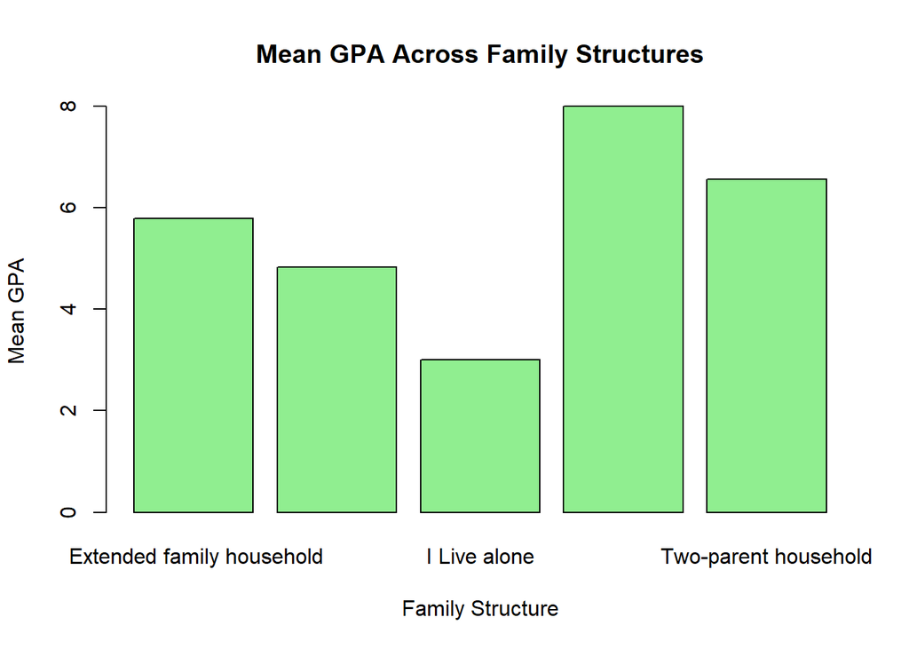

```r
# Compare Mean GPA across family structures
family_gpa_stress <- aggregate(GPA ~ family_structure, data = data_cleaned, mean)

# Create Bar Plot of GPA across Family Structures
barplot(family_gpa_stress$GPA,
        names.arg = family_gpa_stress$family_structure,
        col = "lightgreen",
        main = "Mean GPA Across Family Structures",
        ylab = "Mean GPA",
        xlab = "Family Structure")
```

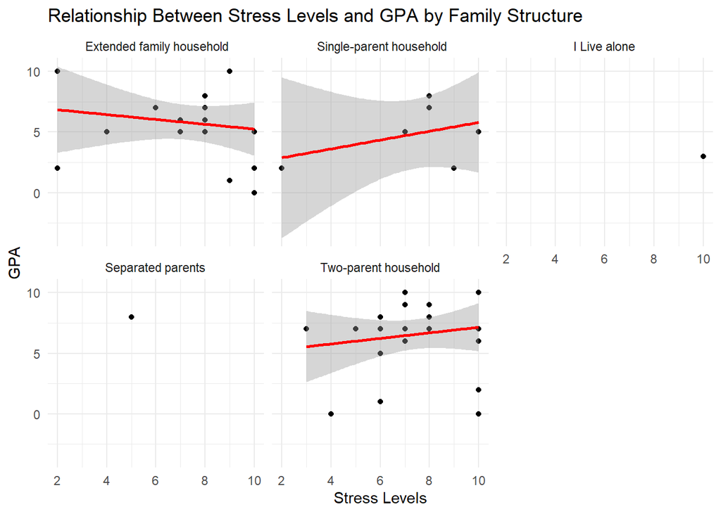

```r
# Scatter Plot of Stress Levels vs GPA with Regression Lines
ggplot(data_cleaned, aes(x = Stress_levels, y = GPA)) +
  geom_point() +
  geom_smooth(method = "lm", col = "red") +
  facet_wrap(~ family_structure) +
  labs(title = "Relationship Between Stress Levels and GPA by Family Structure",
       x = "Stress Levels",
       y = "GPA") +
  theme_minimal()
```

## Family Background: How does family structure influence stress and GPA? - Statistical Summary of GPA and Stress by Family Structure

```r
aggregate(cbind(GPA, Stress_levels) ~ family_structure, data = data_cleaned, mean)
```

```
##             family_structure      GPA Stress_levels
## 1  Extended family household 5.789474      7.315789
## 2    Single-parent household 4.833333      7.333333
## 3               I Live alone 3.000000     10.000000
## 4          Separated parents 8.000000      5.000000
## 5       Two-parent household 6.560000      7.400000
```

## ANOVA: Does Family Structure Affect GPA and Stress?

```r
  anova_gpa <- aov(GPA ~ family_structure, data = data_cleaned)
summary(anova_gpa)
```

```
##                  Df Sum Sq Mean Sq F value Pr(>F)
## family_structure  4   29.8   7.443   0.897  0.474
## Residuals        47  390.2   8.301
```

```r
anova_stress <- aov(Stress_levels ~ family_structure, data = data_cleaned)
summary(anova_stress)
```

```
##                  Df Sum Sq Mean Sq F value Pr(>F)
## family_structure  4  12.62   3.155   0.604  0.662
## Residuals        47 245.44   5.222
```

## Visualization: Boxplots for GPA and Stress by Family Structure

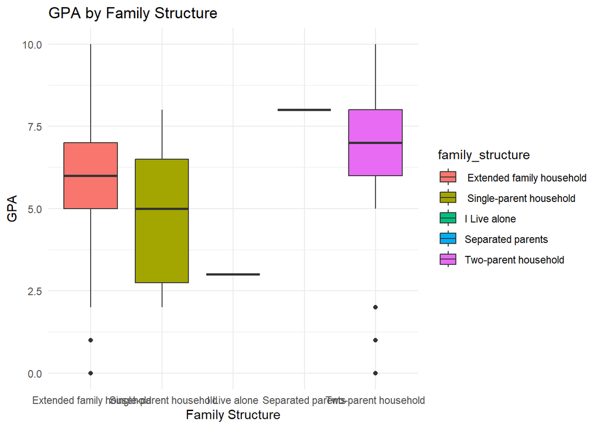

```r
ggplot(data_cleaned, aes(x = family_structure, y = GPA, fill = family_structure)) +
  geom_boxplot() +
  labs(title = "GPA by Family Structure", x = "Family Structure", y = "GPA") +
  theme_minimal()
```

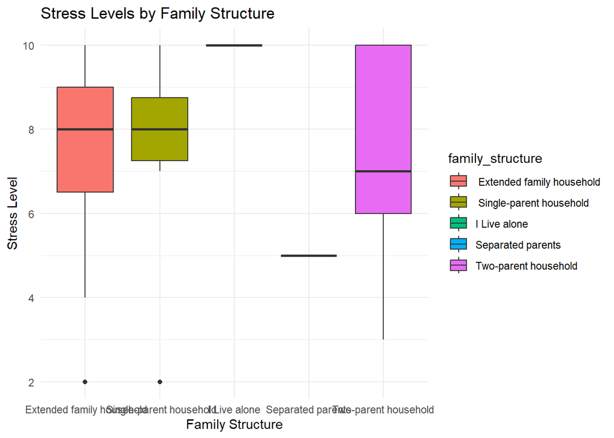

```r
ggplot(data_cleaned, aes(x = family_structure, y = Stress_levels, fill = family_structure)) +
  geom_boxplot() +
  labs(title = "Stress Levels by Family Structure", x = "Family Structure", y = "Stress Level") +
  theme_minimal()
```

## Educational Level: Does level of education impact stress and coping strategies?

```r
aggregate(cbind(Stress_levels, frequency_of_coping) ~ parents_education_level, data = data_cleaned, mean)
```

```
##       parents_education_level Stress_levels frequency_of_coping
## 1         No formal education      8.000000                 7.0
## 2              Primary school      7.750000                 6.0
## 3            Secondary school      6.400000                 9.2
## 4 University degree or higher      7.428571                 6.1
```

```r
anova_edu_stress <- aov(Stress_levels ~ parents_education_level, data = data_cleaned)
summary(anova_edu_stress)
```

```
##                         Df Sum Sq Mean Sq F value Pr(>F)
## parents_education_level  3   5.82   1.941   0.369  0.775
## Residuals               48 252.24   5.255
```

```r
anova_edu_coping <- aov(frequency_of_coping ~ parents_education_level, data = data_cleaned)
summary(anova_edu_coping)
```

```
##                         Df Sum Sq Mean Sq F value Pr(>F)
## parents_education_level  3     44   14.66    0.85  0.474
## Residuals               48    828   17.25
```

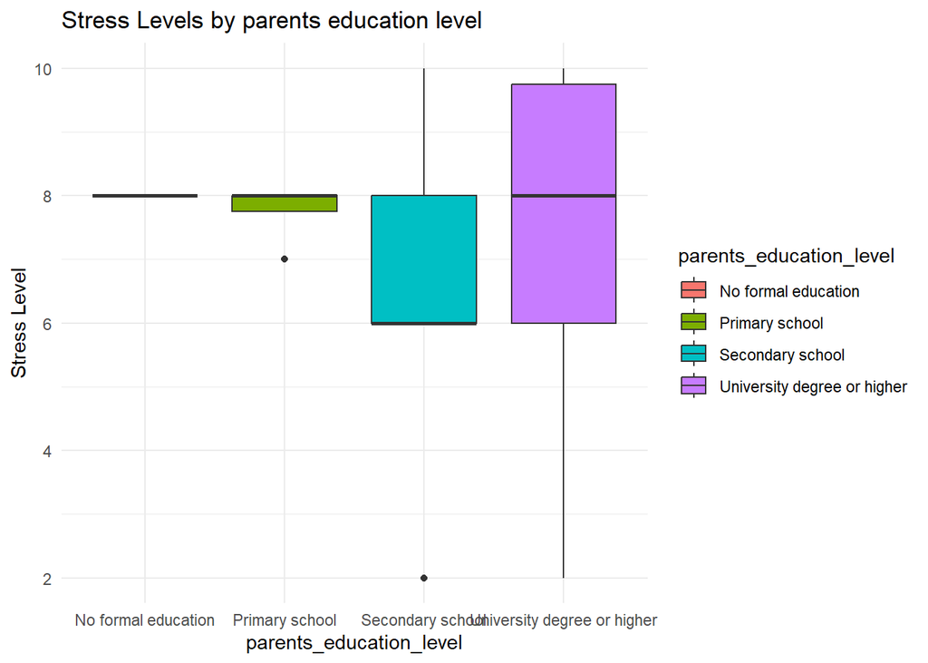

```r
# Visualization: Stress and Coping by Education Level
ggplot(data_cleaned, aes(x = parents_education_level, y = Stress_levels, fill = parents_education_level)) +
  geom_boxplot() +
  labs(title = "Stress Levels by parents education level", x = "parents_education_level", y = "Stress Level") +
  theme_minimal()
```

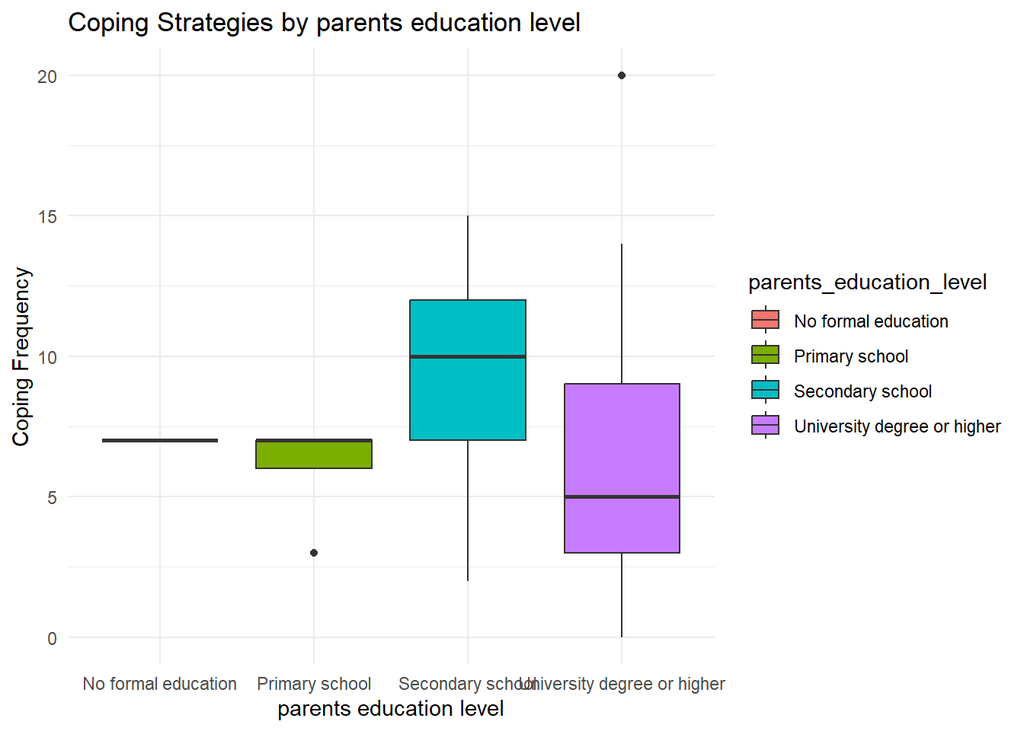

```r
ggplot(data_cleaned, aes(x = parents_education_level, y = frequency_of_coping, fill = parents_education_level)) +
  geom_boxplot() +
  labs(title = "Coping Strategies by parents education level", x = "parents education level", y = "Coping Frequency") +
  theme_minimal()
```

# Access to Resources: How does digital access impact academic success?

```r
aggregate(GPA ~ digital_access, data = data_cleaned, mean)
```

```
##     digital_access      GPA
## 1 Excellent access 5.352941
## 2      Good access 6.636364
## 3   Limited access 6.666667
## 4  Moderate access 5.700000
```

```r
anova_digital_gpa <- aov(GPA ~ digital_access, data = data_cleaned)
summary(anova_digital_gpa)
```

```
##                Df Sum Sq Mean Sq F value Pr(>F)
## digital_access  3   18.2   6.061   0.724  0.543
## Residuals      48  401.7   8.370
```

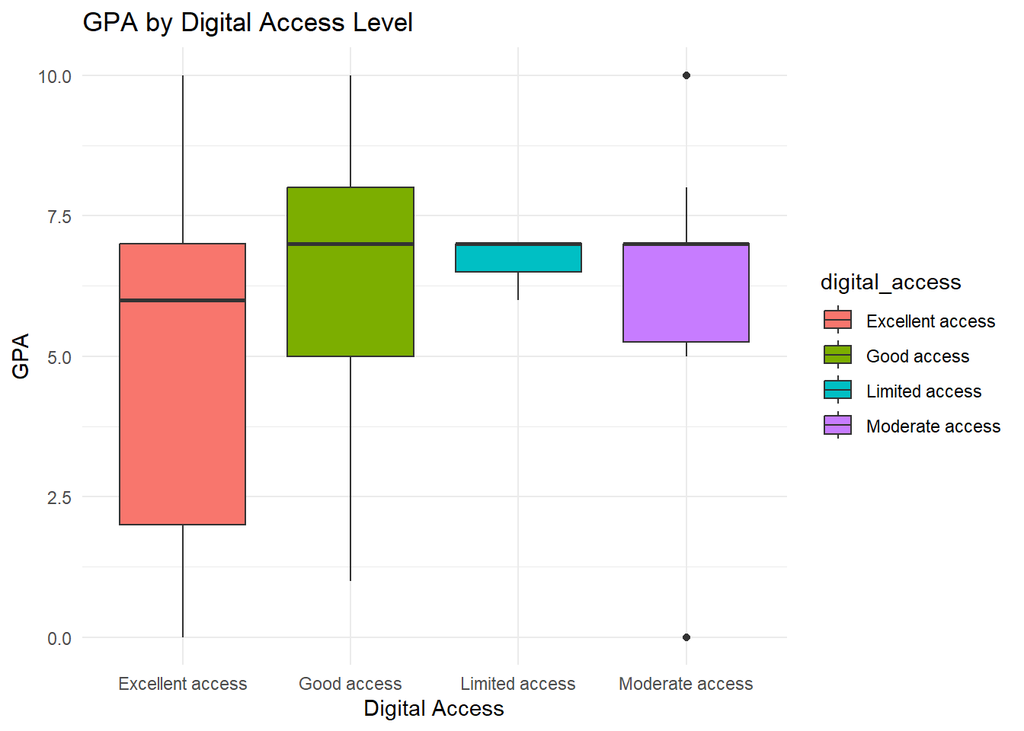

```r
ggplot(data_cleaned, aes(x = digital_access, y = GPA, fill = digital_access)) +
  geom_boxplot() +
  labs(title = "GPA by Digital Access Level", x = "Digital Access", y = "GPA") +
  theme_minimal()
```